# Transmitting affective job insecurity (AJI) within teams: Layoff effects of AJI convergence on intrateam power struggles and team outcomes

Converted from PDF `Lam-TeamAffectiveJobInsecurity-2023-JOB.pdf` · 16 pages · anchors: page `#pN`, block `#pN-bK`

Page 1

#### R E S E A R C H A R T I C L E

C o l l e c t i v e R e a c t i o n s t o O r g a n i z a t i o n a l C h a n g e

## Transmitting affective job insecurity (AJI) within teams: Layoff effects of AJI convergence on intrateam power struggles and team outcomes

Wing Lam<sup>1</sup> | Ziguang Chen<sup>2</sup> | Wen Wu<sup>3</sup> | Cynthia Lee<sup>4</sup>

1Alliance Manchester Business School, The University of Manchester, Manchester, UK

2College of Business, Law and Social Sciences, University of Derby, Derby, UK

3School of Economics and Management, Beijing Jiaotong University, Beijing, China

4D'Amore-McKim School of Business, Northeastern University, Boston, Massachusetts, USA

Correspondence Wen Wu, School of Economics and Management, Beijing Jiaotong University, Beijing, China. Email: wuwen@bjtu.edu.cn

Funding information This research was supported by a grant from the Research Grant Council of the HKSAR, China (GRF no. 15505519) awarded to Wing Lam, Ziguang Chen, and Cynthia Lee, and a grant from Beijing Social Science Funding Project (No. B16HZ00150).

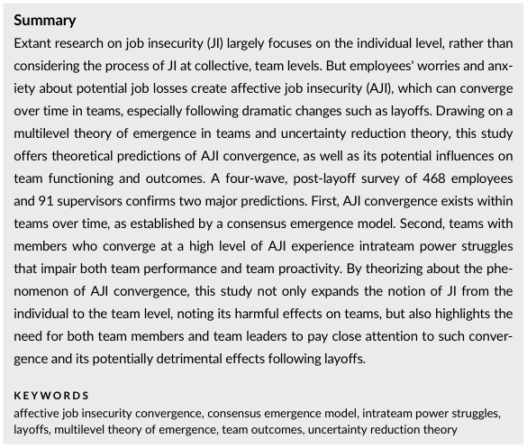

NOTE: figure/graphic rendered as an image from the PDF; its content is not machine-readable text. Caption (if any) follows as the next block.

**text found inside the figure**

Summary

Extant research on job insecurity (JI) largely focuses on the individual level, rather than

considering the process of JI at collective, team levels. But employees' worries and anx-

iety about potential job losses create affective job insecurity (AJI), which can converge

over time in teams, especially following dramatic changes such as layoffs. Drawing on a

multilevel theory of emergence in teams and uncertainty reduction theory, this study

offers theoretical predictions of AJI convergence, as well as its potential influences on

team functioning and outcomes. A four-wave, post-layoff survey of 468 employees

and 91 supervisors confirms two major predictions. First, AJI convergence exists within

teams over time, as established by a consensus emergence model. Second, teams with

members who converge at a high level of AJI experience intrateam power struggles

that impair both team performance and team proactivity. By theorizing about the phe-

nomenon of AJI convergence, this study not only expands the notion of JI from the

individual to the team level, noting its harmful effects on teams, but also highlights the

need for both team members and team leaders to pay close attention to such conver-

gence and its potentially detrimental effects following layoffs.

K E Y W O R D S

affective job insecurity convergence, consensus emergence model, intrateam power struggles, layoffs, multilevel theory of emergence, team outcomes, uncertainty reduction theory

### 1 | INTRODUCTION

The rapid changes, substantial turbulence, and great uncertainty that

characterize today's business environments (Andersen, 2022) imply

that to keep pace with technological advances, shifting markets, eco-

nomic fluctuations, and intensified competition, organizations must

constantly change and adapt (Nicita, 2019; Rafferty, 2022). These

changes include strategic downsizing efforts to cut costs and increase

organizational efficiency (Sucher & Gupta, 2018). Even if layoffs are

essential to an organization's competitiveness and survival, they leave

employees vulnerable to job losses (Etehadi & Karatepe, 2019; Lee

et al., 2018), which tends to evoke their job insecurity (JI), defined as a

perception of threats to the continuity and stability of currently

experienced employment (Shoss, 2017). Prior literature shows consis-

tently that, as a response to organizational changes, JI has detrimental

effects on employees' satisfaction, job involvement, performance,

organizational commitment, trust, turnover intentions, and well-being

(for a meta-analysis, see Jiang & Lavaysse, 2018; for reviews, see Lee

et al., 2018; Shoss, 2017).

Noting the significance of JI in organizational change contexts,

scholars have called for more research into how it develops. Extant

empirical evidence (Bernhard-Oettel et al., 2013; Debus et al., 2014;

Keim et al., 2014; Loi et al., 2012; Yam et al., 2022) and reviews

(Jiang & Lavaysse, 2018; Lee et al., 2018; Shoss, 2017) reveal that

specific organizational contexts (e.g., those lacking procedural justice

and those that violate psychological contracts with employees),

Received: 13 December 2021 Revised: 22 April 2023 Accepted: 24 May 2023

DOI: 10.1002/job.2726

1078 © 2023 John Wiley & Sons Ltd. J Organ Behav. 2023;44:1078–1093. wileyonlinelibrary.com/journal/job

Page 2

employment contract types (e.g., temporary), new technology

(e.g., human–robot collaborations), and individual differences

(e.g., negative affectivity, locus of control, and low self-esteem) all

contribute to JI perceptions. Such studies deepen understanding of

antecedents that give rise to JI, but they also tend to focus on the

individual level. Limited empirical research addresses JI at collective,

team levels. Yet in downsizing scenarios, employees do not operate in

a social vacuum. They engage in conversations and gossip about the

future of the organization or team, so JI perceptions arise in inherently

social contexts (Hartley et al., 1990; Låstad et al., 2016; Sora

et al., 2009). In particular, teams of employees who must communi-

cate to perform work tasks might readily spread JI perceptions, like a

virus (Moran & Volkwein, 1992; Schneider & Reichers, 1983; Sora

et al., 2013). If one employee expresses concern about being power-

less to maintain a job, do other members of the team start developing

similar worries, in ways that affect team functioning and outcomes?

That is, JI cannot be solely an individual concern, because each indi-

vidual employee is embedded in groups that interact, communicate,

and spread influence. Therefore, individual team members might

spread their JI perceptions, consciously or unconsciously, to fellow

team members or more broadly, which would produce collective JI

reactions to layoffs. We refer this phenomenon as JI convergence,

which we conceptualize as a pattern of increasing similarity in the

affective intensity of JI perceptions among members of a team.

In line with the multilevel theory of emergence (Kozlowski

et al., 2013; Kozlowski & Klein, 2000), we propose that JI conver-

gence represents an emergent phenomenon. As a dynamic process,

convergence occurs over time; such bottom-up, multilevel processes

tend to produce collective, higher-level phenomena (Fulmer &

Ostroff, 2016; Kozlowski & Klein, 2000; Lang et al., 2018). Because

team members likely share common perceptions of change, such that

they develop a collective response to that change (Fulmer &

Ostroff, 2016; Kozlowski & Klein, 2000), we predict that members'

worries about potential job losses might converge with their col-

leagues' similar perceptions over time. In this compositional type of

emergence, which implies strong isomorphism, JI convergence is col-

lective and reflects all the emotional dynamics that spread among

members of the team who undergo the same experience (e.g., layoffs).

In turn, our focus is on affective elements of JI (AJI), rather than

its cognitive form (CJI). We prioritize these employee concerns and

the emotional distress that can arise in response to threats of a job

loss or related changes for three main reasons (Huang et al., 2012;

Jiang & Lavaysse, 2018). First, the affective aspect is the predominant

facet of JI (Jiang & Lavaysse, 2018; Kriz et al., 2021; Lian et al., 2022).

After a layoff, survivors experience emotions such as worry and fear

about their own job security (Huang et al., 2012; Ito &

Brotheridge, 2007; Jiang & Lavaysse, 2018; Kiefer, 2005). Second, AJI

and CJI are conceptually distinct: CJI implies knowledge of JI, but AJI

occurs when a person experiences feelings of being worried or emo-

tionally distressed about a potential loss (Huang et al., 2012; Jiang &

Lavaysse, 2018). People are more likely to express feelings and emo-

tions when they confront change, so theoretically, AJI aligns more

closely with their behaviors and outcomes, as confirmed by previous

studies (Lee et al., 2018; Shoss, 2017). With a meta-analysis, Jiang

and Lavaysse (2018) determine that AJI has stronger links with most

relevant outcomes than does CJI, and it accounts for unique incre-

mental variance in outcomes. Third, by focusing on the affective

aspect of JI, we embed our study in the notion of emotional contagion

(Barsade, 2002; Hatfield et al., 1994), which predicts that social conta-

gion is a precursor of collective emotions (Le Bon, 1895) and that indi-

vidual members influence the emotions of other team members by

consciously or unconsciously inducing emotional states and attitudes

(Barsade, 2002; Hatfield et al., 1994; Sullins, 1991). We also can lever-

age broader literature on emotional convergence and affective emer-

gent phenomena (Fulmer & Ostroff, 2016). Specifically, affect is more

prone to transmitting attitudes and behaviors than cognition (Jiang &

Lavaysse, 2018). Accordingly, we use the term “AJI convergence” as a

precise label to refer to the collective affective intensity of JI for team

members.

Then, we predict that the occurrence of AJI convergence among

team members prompts intrateam power struggles, marked by com-

petitive resource acquisition (Greer & van Kleef, 2010; van Bunderen

et al., 2018). In line with uncertainty reduction theory, which also can

predict team-level uncertainty coping strategies (e.g., Greer & van

Kleef, 2010; van Bunderen, 2018), we anticipate that if team members

feel uncertainty due to their fears of being laid off, and that worri-

some situation is further amplified by AJI convergence, they seek

power over the unsettling environment and thus engage in intrateam

power struggles. Such struggles impair team performance and team

proactivity, because in guarding their power and resources, team

members might fail to share information, reject peers' requests for

help, or devote all their attention to protecting their own benefits

(De Dreu & Weingart, 2003; van Bunderen et al., 2018). By integrat-

ing uncertainty reduction theory, we further anticipate that transmit-

ted perceptions of AJI cause damage, in the form of both power

struggles and impaired team outcomes, following layoffs.

In testing these predictions, this study contributes to organiza-

tional change and JI literature in several ways. First, no organizational

change ever happens in isolation, such that it likely affects everyone

in an organization. An exclusive focus on individual victims' or survi-

vors' responses to organizational layoffs is insufficient, yet most stud-

ies in the organizational change attitude domain investigate responses

at the individual level. Such accounts provide an important base of

knowledge but ignore the relevant influence of the social context and

the relational dynamics among multiple people that cannot be under-

stood in terms of independent entities (Chan, 1998; Kozlowski &

Klein, 2000). Collective variables embody higher-order, socially inter-

active properties that cannot be captured by a simple aggregation of

lower-order, individual variables (Bliese, 2000; Kozlowski &

Klein, 2000). Although social contexts represent a higher level of anal-

ysis, they also are anchored in the emotions, cognitions, and behaviors

of individual employees (Kozlowski & Klein, 2000). We acknowledge

some contributions pertaining to collective reactions to change

(e.g., Bouckenooghe et al., 2019; Jeong & Shin, 2019; Rafferty

et al., 2013), though these studies adopt a static approach

(e.g., aggregated mean scores of reactions) that does not capture the

LAM ET AL. 1079

Page 3

inherently affective dynamics of teams. Furthermore, collective enti-

ties fundamentally feature some degree of convergence or consensus

across members that creates higher-level properties that transcend

any individual member (Chan, 1998; Fulmer & Ostroff, 2016). When

team members develop shared views of and responses to organiza-

tional change, through social interactions, a collective property

emerges and exists at the team level. Therefore, we need a clearer

understanding of the process by which change recipients' collective

reactions to change emerge. We posit that convergence is relevant, in

that it can predict the team's collective receptivity to change as it

develops over time, and we propose a multilevel theoretical frame-

work of this collective concept of AJI convergence and its conse-

quences in a layoff context. Examining the convergence of AJI over

time thus extends organizational change attitude literature that pre-

dominantly pertains to the individual level.

Second, convergence processes involving AJI rarely have been

addressed; with our multilevel theory of composition emergence, we

explore whether and how the affective aspects of JI perceptions con-

verge among team members as collective phenomena over time. We

thereby respond to calls, in both organizational change and JI litera-

ture, for more multilevel examinations of JI processes (Låstad

et al., 2018; Sora et al., 2013), with particular attention to how JI

operates at distinct theoretical levels.

Third, we provide new insights into the effects of AJI on

employee performance and outcomes in a social context (Lee

et al., 2018; Shoss, 2017), because we include team members' internal

power struggles and outcomes in job-insecure team contexts. Even

though prior studies acknowledge the existence of power struggles

and recognize that people strategically compete to improve their posi-

tions in organizations (Bendersky & Hays, 2012; Greer & van

Kleef, 2010), scant empirical research has addressed the effects of

power struggles within teams, especially after layoffs. We provide a

new perspective on how members react to their own sense of power-

lessness over their jobs and uncertainty, in line with uncertainty

reduction theory.

Fourth, our findings offer clear recommendations to both team

members and team leaders: They should pay close attention to the

phenomenon of AJI convergence after layoffs. Converging to high

levels of AJI is detrimental for team functioning and outcomes, due to

the unavoidable power struggles they induce.

### 2 | THEORY AND HYPOTHESES

### 2.1 | The concept of AJI convergence

Technological, organizational, and internal or external changes to

organizations can prompt downsizing initiatives, as a conventional

management response, which increase perceived JI (Keim et al., 2014;

Lee et al., 2018). Prior studies note some psychological implications of

JI, mainly using an individual unit of analysis (Jiang & Lavaysse, 2018),

and outline how individual employees subject to organizational

change tend to react (e.g., Spreitzer & Mishra, 2002; van

Dierendonck & Jacobs, 2012; West, 2000), including how they experi-

ence AJI (Keim et al., 2014; Lee et al., 2018). Worrying about job loss

is not just a personal concern. It also exists at a societal level, as

reflected in change recipients' collective reactions to organizational

change. In studies of the harmful impacts of team-level JI (or the JI cli-

mate) that results from organizational change, JI climate usually gets

defined by data gathered at the individual level, then aggregated to

the team level, and the specified outcomes include diminished job sat-

isfaction, work involvement, organizational commitment, and organi-

zational trust (e.g., Sora et al., 2009, 2013). Låstad et al. (2018)

measure the JI climate by asking individual members directly about

their perceptions. These studies suggest that JI is a social phenome-

non, but static approaches cannot reveal JI as an emergent team pro-

cess. Yet AJI clearly fluctuates over time, and emergence takes time

to unfold and manifest. When a layoff exercise begins, members may

not necessarily share the same degrees of individual AJI. As team

members interact and talk about the layoff though, AJI convergence

likely develops.

Kozlowski and Klein (2000) propose a typology of distinct forms

of emergence, ranging from composition to compilation, which can be

distinguished by the underlying theoretical assumptions. Composition

implies an assumption of isomorphism, such that individual members'

perceptions, feelings, and behaviors grow more similar in response to

the same content. Composition instead describes how collective phe-

nomena emerge in teams when team members communicate, interact,

and exchange information and ideas, while also sharing a common

goal or work context. Thus, a hallmark of composition emergence is

convergence; team members must share a common view or response

to change to develop a collective response (Fulmer & Ostroff, 2016;

Kozlowski & Chao, 2012; Kozlowski & Klein, 2000). In contrast, com-

pilation emergence implies that the contributions individual members

make to the collective are variable, not shared or consistent. In this

view, collective responses to change might emerge from complex pat-

terns of individual change responses, but those responses are not nec-

essarily shared among team members (Fulmer & Ostroff, 2016;

Kozlowski & Chao, 2012; Kozlowski & Klein, 2000). We adopt the for-

mer, composition emergence notion to anticipate the convergence of

AJI over time, because collective AJI phenomena likely emerge

through a process that facilitates the convergence of shared AJI per-

ceptions of a layoff exercise. This context provides a collective setting

for transmitting members' AJI perceptions, facilitating their shared

perceptions of the extent to which they need to worry about being

powerless to maintain a job. These feelings of AJI likely become more

similar over time and lead to the composition emergence of collective

AJI to change.

This theorizing also hinges on contagion by AJI, in line with evi-

dence that affect can converge and emerge due to emotional conta-

gion (Collins et al., 2013; Uy et al., 2021). Psychologists define

collective emotions as the synchronous convergence of affective

responses toward a specific event or object, through a process of

emotional contagion (Parkinson, 2020). Emotional contagion in the

workplace occurs when the emotions and behaviors of one employee

lead to the reflexive production of the same emotions and behaviors

1080 LAM ET AL.

Page 4

by other employees. We might think of emotional contagion like

catching a cold: The “virus” is an emotion, and anyone who catches it

is subject to infection and can pass it on to others. The notion of emo-

tional contagion also acknowledges primitive emotional mimicry pro-

cesses. When people engage in primitive emotional mimicry, they

mimic and synchronize another person's facial expressions, postures,

and movements automatically, which encourages convergence in their

emotions too (Barsade, 2002; Hatfield et al., 1992). For example,

when one person starts giggling during a meeting, other participants

tend to start laughing; fears of COVID-19 spread widely throughout

the world at the height of the pandemic (Wheaton et al., 2021). Emo-

tional contagion results from interactions of various people, such as

mothers and infants (Waters et al., 2017), leaders and subordinates

(Pindek et al., 2020; Sy et al., 2005), team members (Jehn et al., 2013;

Parkinson, 2020), teachers and students (Oberle & Schonert-

Reichl, 2016), and service providers and customers (Du et al., 2011;

Hennig-Thurau et al., 2006; Pugh, 2001). Stress contagion in particu-

lar, as a strongly negative emotion (Blanco-Donoso et al., 2021;

Lazarus, 1993), can involve spouses (Bakker et al., 2008; Waters

et al., 2017; Westman et al., 2004), roommates in dorms

(Joiner, 2003), colleagues (Bakker & Schaufeli, 2000; Petitta &

Jiang, 2020), or even work-from-home colleagues (Blanco-Donoso

et al., 2021).

In organizational behavior literature pertaining to team-level

emotional contagion, Barsade (2002) proposes that team members

continuously influence one another's emotions and behaviors. During

interactions, each member tends to reflect the emotional state of the

other person through emotional mimicry, which is automatic

(Chartrand & Bargh, 1999) and induces convergent subjective feel-

ings (Hatfield et al., 1994). In confirmatory evidence of mimicry-

based emotional contagion, Dimberg et al. (2000) measure people's

spontaneous reactions using distinct facial electromyographic gauges

of emotion-relevant facial muscles after being exposed to others'

angry and happy faces. Walter and Bruch (2008) also propose a

group effect spiral, such that one member's emotions quickly transfer

to other team members and initiate a self-reinforcing spiral as that

emotional contagion continues to spread. Primitive emotional mim-

icry is sufficient for emotional contagion in teams, because members

can easily catch the emotions of those with whom they closely inter-

act (Barsade, 2002). Bakker et al. (2008) in particular demonstrate

that expressions of distress, dissatisfaction, or exhaustion produce

corresponding observed and self-reported emotions in others. With

multiple waves of data from Russian military couples, Westman et al.

(2004) show how distress experienced by one spouse can transmit to

the other. The primitive process of emotional contagion involves a

relatively subconscious, automatic transmission of emotion, due to

mimicry (Barsade, 2002). Negative emotions, such as being

depressed, fearful, and anxious, can be readily observed in facial

expressions, postures, and body movements (Critchley &

Nagai, 2012). In interactions with team members who display such

negative emotions, colleagues likely experience the symptoms of

feeling depressed, fearful, and stressed too (Totterdell et al., 2012;

Zagenczyk et al., 2020). Such primitive emotional mimicry implies

that team members see others' AJI and then imitate and synchronize

with it, such that these observations tend to increase the strength of

members' own insecure feelings about their job. Members then per-

ceive that they share the same worries, which evokes widespread AJI

transmission.

Emotional contagion feeds on itself and grows over time to mani-

fest as a collective, emergent phenomenon. It may spread beyond

dyads to get the wider group into sync (Parkinson, 2020). As we have

noted, the emotional states of team members tend to converge over

time (Fulmer & Ostroff, 2016), and convergence processes effectively

account for team members' tendencies to feel and behave in collec-

tive ways (Owens & Hekman, 2016; Totterdell et al., 1998). Collective

emotions thus arise (Goldenberg et al., 2020; von Scheve &

Ismer, 2013). According to the multilevel theory of emergence

(Kozlowski et al., 2013; Kozlowski & Klein, 2000), composition emer-

gence occurs in work teams when individual affect (or behaviors or

attitudes) gets amplified by interactions, such that it manifests as a

higher-level, collective phenomenon, reflecting all emotional dynamics

that appear among employees subject to the same context (i.e., layoff

initiatives in this study). Emotional dynamics refer to emotional conta-

gion and synchronous convergence in affective responses to a specific

event (Goldenberg et al., 2020; Smith & Mackie, 2016). According to

George (1996), when team members' emotional levels are consistent,

a broader “affective tone” arises and serves as social information to

guide members' actions (Parkinson, 1996). In summary, noting evi-

dence that JI is a common (negative) reaction to organizational

changes (Shoss, 2017), we hypothesize that team members influence

one another's AJI perceptions, because they express their AJI and

get exposed to others' AJI, especially after layoffs. As such, the AJI

of work team members tends to converge over time. Formally,

we predict:

H1. AJI convergence occurs among team members

over time following layoffs.

### 2.2 | Consequences of AJI convergence

Employees do not want to wait passively to be laid off, so it is perti-

nent to examine how they react to collective AJI convergence in

uncertain change contexts. Convergence should create a collective

sense of AJI that may push teams to take action. Yet it is insufficient

to consider only the main effect of collective AJI convergence on

team consequences, because our conceptualization entails the

increasing similarity of AJI among team members over time. An AJI

convergence effect might involve increasing similarity of JI at a gener-

ally higher level or increasing similarity of AJI at a lower level. Some

teams may include members who converge to a high level of AJI,

while others feature members converging to a low or modest level.

We thus adopt Uy et al.'s (2021) theorizing about the effect of passion

convergence to predict that the impact of AJI convergence on team

outcomes is moderated by the end state of AJI, toward which team

members are converging.

LAM ET AL. 1081

Page 5

As team members converge to a high level of AJI, due to layoffs,

they suffer uncertainty, fear, worry, and a sense of being lost.

Employees likely wonder how long they can keep their jobs or worry

they will not be able to find jobs elsewhere. Such a context induces

conflict and competition, because the more worried people are about

losing their jobs, the more they seek to make visible contributions and

ensure their supervisors are aware of those contributions, as a protec-

tive mechanism (Shoss et al., 2022). Active coping attempts also might

include proactive efforts to manage, modify, or prevent subsequently

escalated feelings of JI (Aspinwall & Taylor, 1997; Langerak

et al., 2022). As suggested by research into how teams cope with

uncertainty (e.g., Greer & van Kleef, 2010; van Bunderen, 2018), we

adopt uncertainty reduction theory. That is, uncertainty evokes a

sense of insufficient control, which motivates people to seek to regain

their sense of control as a way to cope (Greenberger &

Strasser, 1986). In particular, they might compete for more power, as

a means to replenish their sense of control in uncertain contexts (Fast

et al., 2009; Kraus et al., 2009; van Bunderen et al., 2018). Power

within teams is finite, so one member's power gain implies another

member's power loss (Magee & Galinsky, 2008). Competition for

power in uncertain settings likely leads to intrateam power struggles

(van Bunderen, 2018). Rather than working cooperatively, members

fight over internal resources, in their attempt to control others, miti-

gate their uncertainty, and protect their resources. In line with this

reasoning, we predict that when team members are converging to a

high level of AJI, they compete for resources and control, to protect

themselves and cope with the aversive situation, resulting in promi-

nent power struggles. In contrast, if members are converging to a low

level of AJI, they worry less about losing their jobs and may be less

likely to fight for resources or power. In summary,

H2. The positive relationship between AJI convergence

and intrateam power struggles is stronger if the state of

AJI toward which members are converging is high.

A competitive coping strategy can impair team performance and

team proactivity. Power struggles distract members from their work

(De Dreu & Weingart, 2003; Jehn, 1995; van Bunderen et al., 2018),

because employees focus on maximizing their self-interest and man-

aging their own resources rather than attending to their daily work

tasks. Moreover, power struggles tend to damage members' relation-

ships, in that team members engage in competitive behaviors such as

sabotaging, undermining, purposely withholding important informa-

tion, or refusing to cooperate (van Bunderen et al., 2018), which are

crucial to team performance (Mesmer-Magnus & DeChurch, 2009). In

addition, power struggles tend to be unpleasant and political, so

employees subjected to them are less likely to proactively seek

improvements at work and instead might behave unethically

(Harvey & Harris, 2010; Petrou et al., 2019). Their proactive efforts

already are risky, because leaders might respond negatively (Bolino

et al., 2017; Lanaj & Jennings, 2020) or their action might not be wel-

comed by supervisors and colleagues (Fast et al., 2014; Grant &

Ashford, 2008). As such, power struggles decrease the likelihood of

proactive efforts, shifting members' attention to their own concerns

and agendas related to control and resources. When team members

converge to a high level of AJI, we predict that their competition for

resources and control intensifies, so they focus even less on team

activities and responsibilities. If power struggles disrupt effective

teamwork and impede team performance and team proactivity, we

accordingly anticipate a mediated moderation effect:

H3. Intrateam power struggles mediate the effect of

AJI convergence at a high level on (a) team performance

and (b) team proactivity after layoffs.

Figure 1 depicts the proposed research model.

### 3 | METHODOLOGY

### 3.1 | Research context and data collection

We collected data from a large textile company in northern China,

with a long history (more than 30 years) of competing in the textile

industry. Its business is varied and broad, such that it engages in raw

material processing and producing, R&D for new clothing materials,

manufacturing, designing, and retailing. The company maintains a

detailed division of labor and many working teams within each depart-

ment. For example, the procurement department consists of 12 work-

ing teams, specified by fabrics, such as cotton, linen, silk, wool,

leather, chemical fibers, and blends. Our study samples include mem-

bers of the R&D, design, sales, production, procurement, and market-

ing departments. Team leaders/supervisors, officially appointed by

the company, have formal authority over team operations. In their

hierarchical relationships, team leaders are direct supervisors of team

members, and members report to them. Finally, the company has a

functional organizational structure, so it is rare for work units to con-

duct joint projects in which employees might solve problems in a

matrix team.

The company's business was negatively affected by COVID-19.

The sales director, 17 employees, and eight team leaders all agreed,

in our interviews with them, that their business had been harmed

by the pandemic; many customers canceled or delayed purchase

orders. In response, the company sought to downsize, by 15% of its

total employee rolls, to increase its competitiveness. However, not all

work teams were affected equally; core business teams such as chil-

dren's clothing R&D were not affected, but traditional and materials

design teams lost even more than 15% of their members. The majority

of affected teams lost a few team members rather than the

entire team.

As Figure 2 shows, employees returned to in-person work on

March 27, 2020, subsequent to the outbreak of COVID-19 in China in

January 2020. Although the company had no formal social distancing

policy, all employees were required to wear masks and submit to

weekly nucleic acid tests. On April 15, 2020, the top management

team held meetings to discuss the company's challenges and financial

1082 LAM ET AL.

Page 6

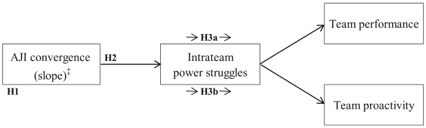

NOTE: figure/graphic rendered as an image from the PDF; its content is not machine-readable text. Caption (if any) follows as the next block.

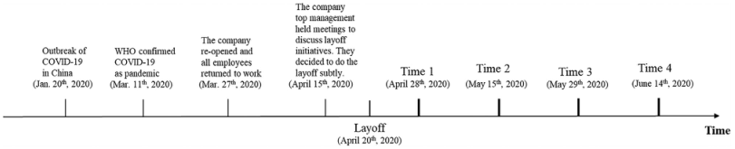

NOTE: figure/graphic rendered as an image from the PDF; its content is not machine-readable text. Caption (if any) follows as the next block.

difficulties; they reached a decision to institute layoffs starting April

20. In our interview, the CEO indicated that the company attempted

to execute layoffs subtly, in the hope of minimizing any sudden nega-

tive effects and maintaining its corporate image. A human resources

(HR) manager and line manager jointly notified individual employees

subject to layoffs, but the company did not openly announce the ini-

tiative. The personal, one-on-one meetings were designed to offer

exiting employees space to address any confusion. Furthermore, the

company paid sufficient layoff compensations, in line with current

labor laws. Based on our in-depth interviews of the company's HR

manager about the layoff agenda and timeline, we chose Time 1, a

week after the substantial layoff, to ask the 144 leaders and 771 sub-

ordinates still employed by the firm to complete a survey. We inter-

viewed the company CEO and 21 layoff survivors, most of whom

expressed concerns about future layoffs, to which they worried they

might fall victim.

A 15-min research orientation, preceding the survey administra-

tion, emphasized that respondents' participation was voluntary and

that all responses were confidential and would be used only for

research purposes. Each subordinate and his or her team leader was

assigned a unique code, so that we could match their responses; the

codes were printed on the questionnaires. The participants were

instructed to put the completed questionnaires into an envelope, seal

it, and submit it directly to the researchers on site.

Then, to test the AJI convergence process, we applied a four-

wave research design. On April 20, 2020, the layoff happened; the

Time 1 survey took place on April 28. Each subsequent survey wave

was separated by 2 weeks. At Time 1, 131 team leaders and 679 sub-

ordinates returned the filled surveys, for usable response rates of

90.97% and 88.06%, respectively. At Time 2 (May 15, approximately

2 weeks after Time 1), 117 team leaders and 604 subordinates

returned the filled surveys, leading to response rates of 89.31% and

88.95%, respectively. At Time 3 (May 29, 2 weeks after Time 2), the

100 team leaders and 544 subordinates represented response rates of

85.47% and 90.06%. Finally, at Time 4 (June 14, 2 weeks after Time

3), 91 team leaders and 468 subordinates represented response rates

of 91.00% and 86.02%, respectively. This group represents our final

sample. That is, only completed responses for the entirety of Time

1 to Time 4 were included in the data set and analyses. Furthermore,

we required each team to provide responses from at least three mem-

bers (in addition to their supervisor) to be included; teams with fewer

than three member responses were excluded from the data set. Each

respondent received an incentive of RMB10 yuan (USD1.5) for

returning each completed survey. Among the 468 employee respon-

dents, 48.08% were women. The average age was 32.6 years

(SD = 5.97), with an average organizational tenure of 10.87 years

(SD = 3.40) and team tenure of 4.92 years (SD = 2.06). Furthermore,

45.51% of the subordinates had at least a college degree. Among the

91 team leaders, 62.64% were women, their average age was

32.37 years (SD = 6.47), 52.75% had a college degree or above, their

average organizational tenure was 6.27 years (SD = 3.15), and their

average team tenure was 4.70 years (SD = 2.02). The average team

size was 5.14 members (SD = 1.13).

### 3.2 | Measures

We used two separate sets of questionnaires for subordinates and

their leaders. Members self-reported their demographic characteris-

tics (Time 1), AJI (Times 1, 2, 3, and 4), and intrateam power struggles

(Time 4). Team leaders provided ratings of team performance (Time 4)

and team proactivity (Time 4). The questionnaire items were originally

written in English and then translated into Chinese using double-blind

back-translation (Brislin et al., 1973).

FIGURE 1 Research model. Note: ‡When team members are converging to a high level of AJI.

FIGURE 2 Timeline of layoffs.

LAM ET AL. 1083

Page 7

### 3.2.1 | Affective job insecurity (AJI)

We assessed subordinates' AJI using 10 items from Huang et al.

(2012). A sample item was “The lack of job security in this company

makes me feel nervous” (1 = strongly disagree, 7 = strongly agree).

The Cronbach's alpha coefficients were .97, .97, .96, and .96 at Times

1, 2, 3, and 4, respectively.

### 3.2.2 | Intrateam power struggles

We assessed intrateam power struggles with three items from Van

Bunderen et al. (2018) and modified them in accordance with Greer

and van Kleef (2010). A sample item was “My team members have

disagreements about who has control in the team” (1 = strongly dis-

agree, 7 = strongly agree) (α = .84). In an analysis of variance, we find

were ICC1 = .21 and ICC2 = .58, and the interrater agreement was

rwg = .79, which indicates high between-team variance and within-

team agreement (Bliese, 2000). When calculating the interrater agree-

ment (rwg), we used a slightly skewed null distribution (LeBreton &

Senter, 2008) for individual intrateam power struggles, because

employees might start to worry about losing their jobs following lay-

offs. Before testing H2 and H3, we aggregated the intrateam power

struggles measure to the team level.

### 3.2.3 | Team performance

Team leaders rated team performance with a three-item measure

developed by De Jong and Elfring (2010), such that they indicated

how the performance of the focal team compares with the perfor-

mance of teams engaged in similar tasks, on three aspects: quality of

output, quantity of output, and overall assessment of team perfor-

mance (1 = very poor, 7 = superb) (α = .95).

### 3.2.4 | Team proactivity

For team proactivity, we used three items from Griffin et al. (2007),

rated by team leaders, such as “Team members developed new and

improved methods to help the work team performs better”

(1 = never, 7 = very often) (α = .95).

### 3.2.5 | Control variables

We controlled for CJI at Time 1 when testing the hypotheses, because

the concept of JI includes both CJI and AJI dimensions. We assessed

subordinates' CJI with 10 items from Oldham et al. (1986), such as

“My job is not a secure one” (1 = strongly disagree; 7 = strongly

agree) (α = .96).

To test H2 and H3, we also controlled for team size, because our

research was embedded in a team context; we measured it as the

number of members on a team. We also controlled for team members'

age diversity, tenure diversity, gender diversity, and education diver-

sity, which can have important effects on team members' interactions

(Joshi & Roh, 2009). We used the coefficient of variation (standard

deviation divided by the group mean) for age and tenure, because

they are continuous demographic variables; we used the Blau (1977)

index for gender and education (lower than college, college, or above).

We also followed Uy et al. (2021) and included each team's AJI simi-

larity at the start of the study (T1) to control for between-team differ-

ences in the initial level of AJI similarity.

### 3.3 | Analytical strategy

To test H1, related to whether AJI convergence occurs among team

members over time, we used a consensus emergence model (CEM),

as developed by Lang et al. (2018). This statistical approach allows

researchers to study the emergence of shared perceptions and feel-

ings in groups over time. As Lang et al. (2018) point out, the concep-

tual rationale for the CEM involves systematically modeling changes

in residual variances over time, to provide insights into the emer-

gence of consensus. Therefore, CEM provides a relevant approach

for determining how team members' AJI becomes more (or less) simi-

lar over time after layoffs, in that it can account for dynamic changes

in group consensus. As suggested by Lang et al. (2018), we use

three-level CEM specifications. The criterion variable is the change in

residual variance; a negative coefficient would indicate that residual

variance decreases over time, that is, that AJI convergence is

occurring.

We rely on Mplus 8.3 to test whether the positive relationship

between AJI convergence and intrateam power struggles is stronger

if the end state of AJI toward which members are converging is

high (H2) and if intrateam power struggles mediate this effect of

AJI convergence at a high level on team performance (H3a) and

team proactivity (H3b). On the basis of our CEM analysis, we esti-

mate team-specific coefficients, which indicate each team's pattern

of AJI convergence over time. These coefficients reflect the slopes

that capture changes in the level of similarity (or dissimilarity) in AJI.

To estimate each team's AJI similarity at the start of the study, we

use the intercept obtained from the model we used to estimate

each team's pattern of AJI convergence. To facilitate interpretation,

we reversed the direction of the scores, by subtracting from 4. Thus,

the original measurement level remains intact; we just reverse the

direction of the variable (Sy & Choi, 2013) to allow larger scores to

denote greater similarity. To measure the level of AJI toward which

members are converging, we used the team-aggregated individual

AJI measures from Time 4. The tests of both H2 and H3 included

the interaction of the team-specific coefficient of AJI convergence

(slope) and team members' average level of AJI at Time 4 as the

independent variable. All variables were grand-mean centered

before the analyses.

1084 LAM ET AL.

Page 8

### 4 | RESULTS

Table 1 contains the means, standard deviations, and correlations of

the team-level variables.

Table 2 presents the results of the omnibus likelihood test of

whether AJI convergence exists over time. The difference between

Model 1b and Model 1a is significant (χ<sup>2</sup> = 15.96, p < .001), which

indicates that including an exponential variance function increases

model fit. The model estimates are in Table 3; it reveals that the expo-

nential variance function weight for time is δ1 = .17 (p < .01). Using

formulas provided by Lang et al. (2018) and Uy et al. (2021), we calcu-

late estimates of the residual variance, based on the model parameters

for Model 1b (Table 3). The residual variance shifts from .36 at Time

1 to .13 at Time 4. Integrating these findings, we can conclude that

within-group residual variance in the data decreases significantly over

time, which signals the occurrence of AJI convergence, in support

of H1.

Figure 3 depicts the H2 and H3 results. In Model B, the standard-

ized coefficient (β = .81, SE = .12, p < .001) indicates that AJI conver-

gence significantly relates to intrateam power struggles if the state to

which members are converging is high AJI. The simple slopes tests,

conducted at high (+1 SD from the mean; b = 1.35, p < .001) and low

(1 SD from the mean; b = .27, p < .05) levels of team AJI, reveal that

AJI convergence positively influences intrateam power struggles when

team members converge to a high level of AJI, but it has a negative

influence when team members converge to a low level (Figure 4).

Thus, we find support for H2.

In the test of H3 (Model A, Figure 3), the standardized coeffi-

cients show that AJI convergence significantly and negatively relates

to team performance (β = .45, SE = .15, p < .01) and team proactiv-

ity (β = .81, SE = .13, p < .001) when the state of AJI toward which

members are converging is high. In Model B, after controlling for the

mediating effect of intrateam power struggles, the standardized coef-

ficients of AJI convergence at a high level become nonsignificant with

regard to team performance (β = .07, SE = .16, n.s.) and less signifi-

cant for team proactivity (β = .45, SE = .14, p < .01). The indirect

effects of AJI convergence at a high level, through intrateam power

struggles, on team performance (β = .38, SE = .11, p < .001) and

team proactivity (β = .36, SE = .10, p < .001) are both significant

and negative. Thus, H3a receives full support, but H3b is only partially

supported.

To clarify this partial mediating effect (H3b), we conduct simple

slopes tests at high (+1 SD) and low (1 SD) levels of team AJI, per-

taining to the relationships between AJI convergence and team proac-

tivity when we control for the mediator (i.e., intrateam power

struggles) or not. Figure 5 contains the results when we do not control

for this mediator (high team AJI: b = 1.00, p < .001; low team AJI:

b = .62, p < .001), and Figure 6 depicts them when we impose this

control (high team AJI: b = .40, p < .05; low team AJI: b = .50,

p < .01). The plots suggest that the influence of AJI convergence on

team proactivity decreases significantly if we control for the intrateam

power struggles (significance level falls from p < .001 to p < .05).

These results further confirm the partial support for H3b.

TABLE 1 Means, standard deviation, and correlations for team-level variables.

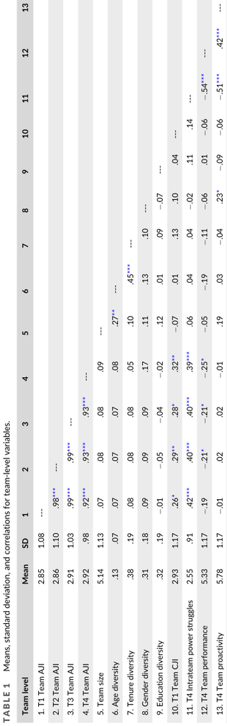

NOTE: complex table shown as an image of the PDF; the text below is a rough machine extraction and may be mis-aligned.

**extracted text (unreliable layout)**

Note: N = 91 teams. T1, Time 1; T2, Time 2; T3, Time 3; T4, Time 4. Age/tenure: in years. Gender: Female = 0; Male = 1. Education: Less than college = 0; College or above = 1.

Abbreviations: AJI, affective job insecurity; CJI, cognitive job insecurity.

*p < .05, **p < .01, and ***p < .001.

LAM ET AL. 1085

Page 9

### 5 | DISCUSSION

Employees face precarious employment situations, reflecting the

global scales of job losses and layoffs. Downsizing is a trigger of JI

(Keim et al., 2014; West, 2000). Employees worry about job conti-

nuity, and such worries can be transmitted to and influence others

within teams, such that AJI convergence occurs. Drawing on a mul-

tilevel theory of emergence (Kozlowski et al., 2013; Kozlowski &

Klein, 2000), we develop a theoretical model of AJI convergence

after layoffs. Our findings offer credible support for the existence

of AJI convergence among team members, as we predicted in H1,

and confirm that when employees begin to worry about job conti-

nuity, they do not necessarily exhibit the same degrees of AJI. As

they interact with other members of the team though, AJI conver-

gence can develop over time. With the tests of H2 and H3, we

show that when members converge to a high level of AJI, it can

create intrateam power struggles, because team members attempt

to alleviate their uncertainty by obtaining greater power and con-

trol. Such strategies ultimately impair team performance and team

proactivity.

### 5.1 | Theoretical and practical implications

Extant research on JI is replete with individual subjective perceptions

(Jiang & Lavaysse, 2018; Lee et al., 2018; Shoss, 2017), even though

worrying about job continuity tends to spread and become a team

perception (Låstad et al., 2018; Sora et al., 2013). Sora et al. (2009)

assert that a JI group climate influences employees' job satisfaction

and commitment, beyond the negative influence of individual percep-

tions. Similarly, Jiang and Probst (2016) conclude that an AJI climate

can predict work safety outcomes (e.g., compliance and injuries), sub-

stantially beyond that explained by individual JI. These findings estab-

lish a social effect of JI in teams; they do not specify how shared

emotional reactions to possible job losses, characterized by anxiety

and fear, might be created though. Team members likely interact to

seek information about the future of the organization after layoffs, so

their perceptions of AJI might be easily transmitted. Through the

spread of rumors or discussion about the future of the organization,

as well as general negative impressions, AJI convergence arises, such

that team members' AJI becomes more similar over time because the

affective intensity of JI gets transmitted throughout the work team. In

indirect support of this reasoning, studies of downsizing note that

people use others' experiences and perceptions to define their own

(Kalimo et al., 2003). We agree with Låstad et al. (2018) that studies

of JI can be effectively informed by a team dynamics lens and thus

build on the multilevel theory of emergence—a collective multilevel

theory that predicts dynamic patterns of synchronous convergence in

affect over time (Kozlowski et al., 2013; Kozlowski & Klein, 2000)—to

develop the concept of AJI convergence. In establishing the process

by which the affective intensity of JI spreads, from the individual to

the collective, team level, we also recommend that continued research

into the social contexts of AJI in workplaces attend to social conver-

gence effects. More broadly, we theorize about and measure collec-

tive reactions to organizational change events; such contexts require

considerations of the content, process, and contingent factors that

can predict collective reactions to organizational change. Our study

offers important implications for organizational change attitude litera-

ture that predominantly addresses the individual level, in that it offers

theorizing and empirical tests of the occurrence of AJI convergence

and its impacts at the collective, team level.

Leveraging previous research on aggregated individual JI, along

with uncertainty reduction theory, we confirm that AJI convergence

induces intrateam power struggles, impairs team performance, and

TABLE 2 Extended consensus emergence models (CEM): Model comparisons.

[output not shown]

NOTE: table converted from PDF layout to HTML text; cell boundaries are reconstructed. See PDF if exact alignment matters.

Note: For both models, N = 1872 observations nested in 468 team members and 91 teams. Abbreviations: AIC, Akaike information criterion; BIC, Bayesian information criterion. ***p < .001.

TABLE 3 Extended consensus emergence model: Model estimates for AJI convergence.

[output not shown]

NOTE: table converted from PDF layout to HTML text; cell boundaries are reconstructed. See PDF if exact alignment matters.

Note: For both models, N = 1872 observations nested in 468 team members and 91 teams. Abbreviations: AJI, affective job insecurity; CJI, cognitive job insecurity; T1, Time 1. *p < .05, **p < .01, and ***p < .001.

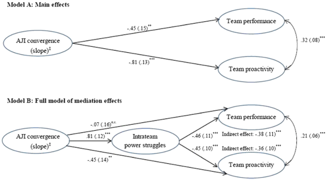

NOTE: figure/graphic rendered as an image from the PDF; its content is not machine-readable text. Caption (if any) follows as the next block.

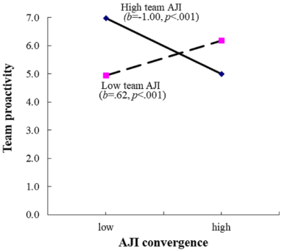

NOTE: figure/graphic rendered as an image from the PDF; its content is not machine-readable text. Caption (if any) follows as the next block.

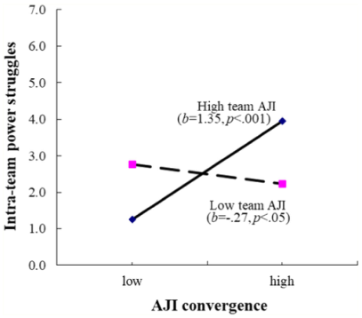

NOTE: figure/graphic rendered as an image from the PDF; its content is not machine-readable text. Caption (if any) follows as the next block.

reduces team proactivity when team members converge to a high

level of AJI. The uncertain situation created by layoffs exposes team

members to resource threats, raising their concerns and tendency to

undertake behaviors that might secure their jobs and resources. By

establishing intrateam power struggles as a key mediating factor of

the collective AJI convergence effect, we also contribute to growing

literature on the social context for JI (usually represented as aggre-

gated individual JI or JI team climate in prior studies) and its influence

on team outcomes (e.g., Låstad et al., 2018; Sora et al., 2013).

Intrateam power struggles provide an underlying mechanism that gov-

erns the effect of AJI convergence at a higher level on team out-

comes. It may be meaningful to explore other mediating mechanisms

too, such as team cohesion or intrateam intrigue, that might explain

the relationship further.

It may be hard to prevent AJI convergence, considering its rather

automatic and unconscious nature, but employees, leaders, and orga-

nizations all would benefit from efforts to mitigate it. As our results

reveal, employees' AJI perceptions can be transmitted and exert wide

FIGURE 3 The path coefficients of the mediation model. Note: <sup>n.s.</sup>Nonsignificant, *p < .05, **p < .01, ***p < .001. ‡When team members are converging to a high level of AJI. Team size, age diversity, tenure diversity, gender diversity, education diversity, CJI (T1), and AJI similarity at T1 were controlled. Only CJI (T1) (.17 [.08]*) and AJI similarity at T1 (.22 [.08]**) have significant effects on the relationships between AJI convergence and intrateam power struggles.

FIGURE 4 Interaction between AJI convergence and team AJI on intrateam power struggles.

FIGURE 5 Interaction between AJI convergence and team AJI on team proactivity without controlling for intrateam power struggles.

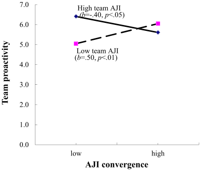

NOTE: figure/graphic rendered as an image from the PDF; its content is not machine-readable text. Caption (if any) follows as the next block.

influences, which generally is not desirable for themselves or their

team. If the future is uncertain, being “mindful” may help. Being mind-

ful entails working to stay focused, without letting the mind wander

into a spiral of uncertain, unpleasant scenarios (Bracci, 2020). Such

efforts foster objectivity and nonjudgmental stances in various situa-

tions, which should help people start to feel more comfortable with

uncertainty or aware of changes (Bracci, 2020). Our findings about

the likelihood of increased power struggles in the face of insecurity

also have practical ramifications for managers. Layoffs are heartbreak-

ing, but they might not be the most emotionally challenging aspect

(Hamid Rao, 2021); uncertainty is. Employees worry for weeks about

the threat of job loss, and as rumors and whispers circulate, the pain

and discomfort of their uncertainty increase even further. Being

exposed to uncertainty and negative anticipation takes a heavy toll on

employee well-being and health (Pollard, 2001). When AJI results in

competitive power struggles, it also can undermine team outcomes.

Team leaders therefore must seek ways to reduce survivors' uncer-

tainty following layoffs; Kriz et al. (2021) suggest active listening as an

important tactic to boost employees' sense of control and reduce their

uncertainty. Active listening by leaders even can have ripple effects,

by increasing employees' perceived control and decreasing their AJI.

Organizations thus should train leaders to be better listeners. If time

and resources allow, they also should establish a clear, ethical, rea-

sonable, and positive layoff strategy and then communicate trans-

parently about the reasons for downsizing, the impacts on victims

and survivors, and the support available to them, which can help

offset uncertainty. The benefits of a carefully planned downsizing

strategy also are evident in Cameron's (1994) study of 30 organiza-

tions that engaged in downsizing over a four-year period. We hope

additional research might establish empirical evidence of the effec-

tiveness of such organizational interventions by simulating the

effects of leader or organizational support on AJI convergence and

outcomes.

### 5.2 | Limitations and further research directions

Our study has several notable strengths, including the time-lagged

data collection in the context of an organization undergoing layoff ini-

tiatives. However, like all studies, it is not without limitations. One

such constraint pertains to the timing of our data collection, which

occurred after the first layoff. When COVID-19 hit, the textile indus-

try was one of the first to feel its effects; in China, production slowed

almost to a halt (The Baltic Times, 2021). The textile company we

study experienced a huge drop in volume and revenue, so its top man-

agement team promptly decided to downsize, shortly after employees

returned to in-person work. The layoffs were unexpected before the

first lockdown in China though (January 2020), and we did not con-

duct any surveys before these layoffs took place. Instead, we col-

lected the first wave 1 week after the layoff, when employees were

aware that if the company could not recover, their jobs would be in

jeopardy too. To build on our findings, researchers might seek a simi-

lar, somewhat more predictable downsizing event to be able to con-

duct “before-and-after” surveys.

We also cannot confidently generalize the findings to other cul-

tural contexts, even though downsizing and layoffs are global phe-

nomena (Andersen, 2022). We posit that AJI convergence and reactions

to it are similar across national cultures. Still, as Debus et al. (2012) find,

in their study of 15 200 employees from 24 counties, employees in

countries that score high on uncertainty avoidance (i.e., extensive

norms, rules, and procedures in place to alleviate uncertainty) who

experience JI also have clearer ideas about what will happen and how

they will be protected in the event of a job loss, so they might have less

negative reactions to JI than employees in cultures with low levels of

uncertainty avoidance. Bluszcz and Quan (2016) categorize China as a

low uncertainty avoidance culture, comfortable with ambiguity. Thus,

the findings might differ somewhat in cultures marked by high uncer-

tainty avoidance. We acknowledge this limitation as a worthy consider-

ation for additional research that could compare findings gathered from

both high- and low-uncertainty avoidance cultures.

The phenomenon of AJI convergence in reaction to change is criti-

cal to understand; it also would be valuable to explore specific factors

that encourage teams to converge to lower or higher levels of AJI. The

existence of emergence phenomena, and their variability, largely reflects

team characteristics, team experience, and relevant team entities

(Kozlowski & Klein, 2000). Identifying factors that facilitate or inhibit

AJI convergence thus would provide a rich perspective onto change

contexts. Research into social ties in organizations indicates that friend-

ship ties and work ties are critical for facilitating information sharing,

decision-making, and socializing (Brass, 1984; Morrison, 2002;

Totterdell et al., 2004); additional research could test whether the qual-

ity of such ties among team members determines the emergence of

higher-level (or collective) change responses. We study AJI convergence

among employees within teams but not across their social networks in

the organizations. Convergence effects might be more salient within

teams, in which employees work in similar contexts and likely share sim-

ilar concerns, fears, and worries. Belonging to the same team facilitates

emotional contagion and the interpersonal transfer of emotions, and

FIGURE 6 Interaction between AJI convergence and team AJI on team proactivity, controlling for intrateam power struggles.

group membership heightens the chances of being exposed to similar,

emotionally relevant events (Parkinson et al., 2005). This reasoning

underlies our decision to examine AJI convergence within teams, but

ongoing research efforts also could explore how social networks facili-

tate AJI convergence. Such an exploration would be particularly rele-

vant to companies that use flatter or matrix structures, with employees

who work closely across departments.

Finally, we acknowledge the possibility that emotional transmis-

sion can occur among team members repeatedly, in a reciprocal spiral.

An anxious team member who worries about losing a job can induce

others to become anxious, and then those others can return their

escalated anxiety to the focal team member, sparking a vicious cycle

of interpersonal transfer of emotions (Hareli & Hess, 2010). We do

not test for boundary conditions of our hypothesized relationships

either. Our focus on the process of AJI convergence may exclude con-

textual effects and boundary conditions, such as those that might

stem from personal traits or situational factors. For example, do neu-

rotic people, who tend to be more sensitive to stressors, increase the

AJI convergence effect? Does job mobility decrease it? Research that

tests these questions could establish important factors that stimulate

AJI convergence and the outcomes that result.

### 6 | CONCLUSION

Because AJI could be convergent, slowing its transmission among

employees is critical during layoffs. This study demonstrates that team

members who attend to the same unpleasant context facilitate emo-

tional connections, escalating to a collective, team-level AJI conver-

gence phenomenon. We hope the theory we propose and the findings

we establish spur further investigations of this process to advance

understanding, in research that theorizes about and measures collec-

tive reactions to organizational change events.

ACKNOWLEDGMENTS

We would like to thank the Special Issue Editorial Team and the three

anonymous reviewers for their insightful and constructive feedback.

We also thank Prof. Mo Wang for the insightful feedback on the ear-

lier draft.

CONFLICT OF INTEREST STATEMENT

The authors certify that they have no potential sources of conflict of

interest with this study and manuscript.

DATA AVAILABILITY STATEMENT

Data available on request from the authors.

ORCID

Wing Lam https://orcid.org/0000-0002-9691-3095

REFERENCES

Andersen, E. (2022). Change is hard. Here's how to make it less painful. In

Harvard business review digital articles (pp. 1–8).

Aspinwall, L. G., & Taylor, S. E. (1997). A stitch in time: Self-regulation and

proactive coping. Psychological Bulletin, 121, 417–436. https://doi. org/10.1037/0033-2909.121.3.417 Bakker, A. B., Demerouti, E., & Dollard, M. F. (2008). How job demands

affect partners' experience of exhaustion: Integrating work-family conflict and crossover theory. Journal of Applied Psychology, 93(4), 901–911. https://doi.org/10.1037/0021-9010.93.4.901 Bakker, A. B., & Schaufeli, W. B. (2000). Burnout contagion processes among

teachers. Journal of Applied Social Psychology, 30(11), 2289–2308. https://doi.org/10.1111/j.1559-1816.2000.tb02437.x Barsade, S. G. (2002). The ripple effect: Emotional contagion and its influence

on group behavior. Administrative Science Quarterly, 47(4), 644–675. https://doi.org/10.2307/3094912 Bendersky, C., & Hays, N. A. (2012). Status conflict in groups. Organization

Science, 23(2), 323–340. https://doi.org/10.1287/orsc.1110.0734 Bernhard-Oettel, C., Rigotti, T., Clinton, M., & De Jong, J. (2013). Job inse-

curity and well-being in the temporary workforce: Testing volition and contract expectations as boundary conditions. European Journal of Work and Organizational Psychology, 22(2), 203–217. https://doi.org/ 10.1080/1359432X.2011.647409 Blanco-Donoso, L. M., Moreno-Jiménez, J., Amutio, A., Gallego-Alberto, L.,

Moreno-Jiménez, B., & Garrosa, E. (2021). Stressors, job resources, fear of contagion, and secondary traumatic stress among nursing home workers in face of the COVID-19: The case of Spain. Journal of Applied Gerontology, 40(3), 244–256. https://doi.org/10.1177/0733464820964153 Blau, P. M. (1977). Inequality and heterogeneity. Free Press. Bliese, P. D. (2000). Within-group agreement, non-independence, and reli-

ability: Implications for data aggregation and analysis. In K. J. Klein & S. W. Kozlowski (Eds.), Multilevel theory, research, and methods in organizations (pp. 349–381). Jossey-Bass. Bluszcz, M., & Quan, S. (2016). Cultural comparison between China and

Germany based on Hofstede and GLOBE. International Journal of Marketing, Financial Services & Management Research, 5(10), 58–68. Bolino, M. C., Turnley, W. H., & Anderson, H. J. (2017). The dark side of

proactive behavior. When being proactive may hurt oneself, others, or the organization. In S. K. Parker & U. K. Bindl (Eds.), Proactivity at work: Making things happen in organizations (pp. 499–529). Taylor & Francis. Bouckenooghe, D., Schwarz, G. M., Hastings, B., & de Pereny, S. G. L.

(2019). Facilitating change through groups: Formation of collective attitudes toward change. In Research in organizational change and development. Emerald Publishing Limited. Bracci, A. (2020). Fear can be contagious. Here are some ideas for keeping

calm. Retrieved July 13, 2022, from https://news.northeastern.edu/ 2020/03/10/fear-can-be-contagious-here-are-some-ways-to-protectyourself/#_ga=2.56534179.904625612.1657666908-1781558356. 1657666908 Brass, D. J. (1984). Being in the right place: A structural analysis of individ-

ual influence in an organization. Administrative Science Quarterly, 29, 518–539. https://doi.org/10.2307/2392937 Brislin, R., Lonner, W. J., & Thorndike, R. (1973). Cross-cultural research

methods. Wiley. Cameron, K. S. (1994). Strategies for successful organizational downsizing.

Human Resource Management, 33(2), 189–211. https://doi.org/10. 1002/hrm.3930330204 Chan, D. (1998). Functional relations among constructs in the same con-

tent domain at different levels of analysis: A typology of composition models. Journal of Applied Psychology, 83(2), 234–246. https://doi.org/ 10.1037/0021-9010.83.2.234 Chartrand, T. L., & Bargh, J. A. (1999). The chameleon effect: The

perception–behavior link and social interaction. Journal of Personality and Social Psychology, 76(6), 893–910. https://doi.org/10.1037/0022- 3514.76.6.893 Collins, A. L., Lawrence, S. A., Troth, A. C., & Jordan, P. J. (2013). Group

affective tone: A review and future research directions. Journal of Organizational Behavior, 34(S1), S43–S62. https://doi.org/10.1002/job.1887

Critchley, H. D., & Nagai, Y. (2012). How emotions are shaped by bodily

states. Emotion Review, 4(2), 163–168. https://doi.org/10.1177/ 1754073911430132 De Dreu, C. K., & Weingart, L. R. (2003). Task versus relationship conflict,

team performance, and team member satisfaction: A meta-analysis. Journal of Applied Psychology, 88(4), 741–749. https://doi.org/10. 1037/0021-9010.88.4.741 De Jong, B. A., & Elfring, T. (2010). How does trust affect the performance

of ongoing teams? The mediating role of reflexivity, monitoring, and effort. Academy of Management Journal, 53(3), 535–549. https://doi. org/10.5465/amj.2010.51468649 Debus, M. E., König, C. J., & Kleinmann, M. (2014). The building blocks of

job insecurity: The impact of environmental and person-related variables on job insecurity perceptions. Journal of Occupational and Organizational Psychology, 87(2), 329–351. https://doi.org/10.1111/joop.12049 Debus, M. E., Probst, T. M., König, C. J., & Kleinmann, M. (2012). Catch me

if I fall! Enacted uncertainty avoidance and the social safety net as country-level moderators in the job insecurity–job attitudes link. Journal of Applied Psychology, 97(3), 690–698. https://doi.org/10.1037/ a0027832 Dimberg, U., Thunberg, M., & Elmehed, K. (2000). Unconscious facial reac-

tions to emotional facial expressions. Psychological Science, 11(1), 86–89. https://doi.org/10.1111/1467-9280.00221 Du, J., Fan, X., & Feng, T. (2011). Multiple emotional contagions in service

encounters. Journal of the Academy of Marketing Science, 39(3), 449–466. https://doi.org/10.1007/s11747-010-0210-9 Etehadi, B., & Karatepe, O. M. (2019). The impact of job insecurity on criti-

cal hotel employee outcomes: The mediating role of self-efficacy. Journal of Hospitality Marketing & Management, 28(6), 665–689. https:// doi.org/10.1080/19368623.2019.1556768 Fast, N. J., Burris, E. R., & Bartel, C. A. (2014). Managing to stay in the dark:

Managerial self-efficacy, ego defensiveness, and the aversion to employee voice. Academy of Management Journal, 57(4), 1013–1034. https://doi.org/10.5465/amj.2012.0393 Fast, N. J., Gruenfeld, D. H., Sivanathan, N., & Galinsky, A. D. (2009). Illu-

sory control: A generative force behind power's far-reaching effects. Psychological Science, 20(4), 502–508. https://doi.org/10.1111/j. 1467-9280.2009.02311.x Fulmer, C. A., & Ostroff, C. (2016). Convergence and emergence in organi-

zations: An integrative framework and review. Journal of Organizational Behavior, 37(S1), S122–S145. https://doi.org/10.1002/job.1987 George, J. M. (1996). Group affective tone. In M. West (Ed.), Handbook of

work group psychology (pp. 77–93). Wiley. Goldenberg, A., Garcia, D., Halperin, E., & Gross, J. J. (2020). Collective

emotions. Current Directions in Psychological Science, 29(2), 154–160. https://doi.org/10.1177/0963721420901574 Grant, A. M., & Ashford, S. J. (2008). The dynamics of proactivity at work.

Research in Organizational Behavior, 28, 3–34. https://doi.org/10. 1016/j.riob.2008.04.002 Greenberger, D. B., & Strasser, S. (1986). Development and application

of a model of personal control in organizations. Academy of Management Review, 11(1), 164–177. https://doi.org/10.5465/amr.1986. 4282657 Greer, L. L., & van Kleef, G. A. (2010). Equality versus differentiation:

The effects of power dispersion on group interaction. Journal of Applied Psychology, 95(6), 1032–1044. https://doi.org/10.1037/ a0020373 Griffin, M. A., Neal, A., & Parker, S. K. (2007). A new model of work role

performance: Positive behavior in uncertain and interdependent contexts. Academy of Management Journal, 50(2), 327–347. https://doi. org/10.5465/amj.2007.24634438 Hamid Rao, A. (2021). When you know layoffs are coming. In Harvard busi-

ness review digital articles (pp. 1–5). Hareli, S., & Hess, U. (2010). What emotional reactions can tell us about

the nature of others: An appraisal perspective on person perception.

Cognition and Emotion, 24(1), 128–140. https://doi.org/10.1080/ 02699930802613828 Hartley, J., Jacobson, D., Klandermans, B., & Van Vuuren, T. (1990). Job

insecurity: Coping with jobs at risk. Sage Publications Ltd. Harvey, P., & Harris, K. J. (2010). Frustration-based outcomes of entitle-

ment and the influence of supervisor communication. Human Relations, 63(11), 1639–1660. https://doi.org/10.1177/0018726710362923 Hatfield, E., Cacioppo, J. T., & Rapson, R. L. (1992). Primitive emotional

contagion. In M. S. Clark (Ed.), Review of personality and social psychology: Emotion and social behavior (Vol. 14, pp. 151–177). Sage. Hatfield, E., Cacioppo, J. T., & Rapson, R. L. (1994). Emotional contagion.

Cambridge University Press. Hennig-Thurau, T., Groth, M., Paul, M., & Gremler, D. D. (2006). Are all

smiles created equal? How emotional contagion and emotional labor affect service relationships. Journal of Marketing, 70(3), 58–73. https:// doi.org/10.1509/jmkg.70.3.058 Huang, G. H., Niu, X., Lee, C., & Ashford, S. J. (2012). Differentiating cog-

nitive and affective job insecurity: Antecedents and outcomes. Journal of Organizational Behavior, 33(6), 752–769. https://doi.org/10.1002/ job.1815 Ito, J. K., & Brotheridge, C. M. (2007). Exploring the predictors and conse-

quences of job insecurity's components. Journal of Managerial Psychology, 22(1), 40–64. https://doi.org/10.1108/02683940710721938 Jehn, K., Rispens, S., Jonsen, K., & Greer, L. (2013). Conflict contagion: A

temporal perspective on the development of conflict within teams. International Journal of Conflict Management, 24(4), 352–373. https:// doi.org/10.1108/IJCMA-05-2011-0039 Jehn, K. A. (1995). A multimethod examination of the benefits and detri-

ments of intragroup conflict. Administrative Science Quarterly, 40(2), 256–282. https://doi.org/10.2307/2393638 Jeong, I., & Shin, S. J. (2019). High-performance work practices and organi-

zational creativity during organizational change: A collective learning perspective. Journal of Management, 45(3), 909–925. https://doi.org/ 10.1177/0149206316685156 Jiang, L., & Lavaysse, L. M. (2018). Cognitive and affective job insecurity: A

meta-analysis and a primary study. Journal of Management, 44(6), 2307–2342. https://doi.org/10.1177/0149206318773853 Jiang, L., & Probst, T. M. (2016). A multilevel examination of affective job

insecurity climate on safety outcomes. Journal of Occupational Health Psychology, 21(3), 366–377. https://doi.org/10.1037/ocp0000014 Joiner, T. E. (2003). Contagion of suicidal symptoms as a function of assor-

tative relating and shared relationship stress in college roommates. Journal of Adolescence, 26(4), 495–504. https://doi.org/10.1016/ S0140-1971(02)00133-1 Joshi, A., & Roh, H. (2009). The role of context in work team diversity

research: A meta-analytic review. Academy of Management Journal, 52(3), 599–627. https://doi.org/10.5465/amj.2009.41331491 Kalimo, R., Taris, T. W., & Schaufeli, W. B. (2003). The effects of past and

anticipated future downsizing on survivor well-being: An equity perspective. Journal of Occupational Health Psychology, 8(2), 91–109. https://doi.org/10.1037/1076-8998.8.2.91 Keim, A. C., Landis, R. S., Pierce, C. A., & Earnest, D. R. (2014). Why do

employees worry about their jobs? A meta-analytic review of predictors of job insecurity. Journal of Occupational Health Psychology, 19(3), 269–290. https://doi.org/10.1037/a0036743 Kiefer, T. (2005). Feeling bad: Antecedents and consequences of negative

emotions in ongoing change. Journal of Organizational Behavior, 26(8), 875–897. https://doi.org/10.1002/job.339 Kozlowski, S. W., & Chao, G. T. (2012). The dynamics of emergence: Cog-

nition and cohesion in work teams. Managerial and Decision Economics, 33(5–6), 335–354. https://doi.org/10.1002/mde.2552 Kozlowski, S. W. J., Chao, G. T., Grand, J. A., Braun, M. T., & Kuljanin, G.

(2013). Advancing multilevel research design: Capturing the dynamics of emergence. Organizational Research Methods, 16(4), 581–615. https://doi.org/10.1177/109442811349311

Kozlowski, S. W. J., & Klein, K. J. (2000). A multilevel approach to theory

and research in organizations: Contextual, temporal, and emergent processes. In K. J. Klein & S. W. J. Kozlowski (Eds.), Multilevel theory, research and methods in organizations: Foundations, extensions, and new directions (pp. 3–90). Jossey-Bass. Kraus, M. W., Piff, P. K., & Keltner, D. (2009). Social class, sense of control,

and social explanation. Journal of Personality and Social Psychology, 97(6), 992–1004. https://doi.org/10.1037/a0016357 Kriz, T. D., Jolly, P. M., & Shoss, M. K. (2021). Coping with organizational

layoffs: Managers' increased active listening reduces job insecurity via perceived situational control. Journal of Occupational Health Psychology, 26(5), 448–458. https://doi.org/10.1037/ocp0000295 Lanaj, K., & Jennings, R. E. (2020). Putting leaders in a bad mood: The

affective costs of helping followers with personal problems. Journal of Applied Psychology, 105(4), 355–371. https://doi.org/10.1037/ apl0000450 Lang, J. W., Bliese, P. D., & de Voogt, A. (2018). Modeling consensus emer-

gence in groups using longitudinal multilevel methods. Personnel Psychology, 71(2), 255–281. https://doi.org/10.1111/peps.12260 Langerak, J. B., Koen, J., & van Hooft, E. A. J. (2022). How to minimize job

insecurity: The role of proactive and reactive coping over time. Journal of Vocational Behavior, 136, 103724. https://doi.org/10.1016/j.jvb. 2022.103724 Låstad, L., Näswall, K., Berntson, E., Seddigh, A., & Sverke, M. (2018). The

roles of shared perceptions of individual job insecurity and job insecurity climate for work-and health-related outcomes: A multilevel approach. Economic and Industrial Democracy, 39(3), 422–438. https:// doi.org/10.1177/0143831X16637129 Låstad, L., Vander Elst, T., & De Witte, H. (2016). On the reciprocal rela-

tionship between individual job insecurity and job insecurity climate. Career Development International, 21(3), 246–261. https://doi.org/10. 1108/CDI-03-2015-0046 Lazarus, R. S. (1993). From psychological stress to the emotions: A history

of changing outlooks. Annual Review of Psychology, 44(1), 1–22. https://doi.org/10.1146/annurev.ps.44.020193.000245 Le Bon, G. (1895). The crowd: A study of the popular mind. T. Fisher Unwin. LeBreton, J. M., & Senter, J. L. (2008). Answers to 20 questions about interra-

ter reliability and interrater agreement. Organizational Research Methods, 11(4), 815–852. https://doi.org/10.1177/1094428106296642 Lee, C., Huang, G.-H., & Ashford, S. J. (2018). Job insecurity and the chang-

ing workplace: Recent developments and the future trends in job insecurity research. Annual Review of Organizational Psychology and Organizational Behavior, 5, 335–359. https://doi.org/10.1146/ annurev-orgpsych-032117-104651 Lian, H., Li, J. K., Du, C., Wu, W., Xia, Y., & Lee, C. (2022). Disaster or

opportunity? How COVID-19-associated changes in environmental uncertainty and job insecurity relate to organizational identification and performance. Journal of Applied Psychology, 107(5), 693–706. https://doi.org/10.1037/apl0001011 Loi, R., Lam, L. W., & Chan, K. W. (2012). Coping with job insecurity: The

role of procedural justice, ethical leadership and power distance orientation. Journal of Business Ethics, 108(3), 361–372. https://doi.org/10. 1007/s10551-011-1095-3 Magee, J. C., & Galinsky, A. D. (2008). 8 social hierarchy: The self-reinforcing

nature of power and status. Academy of Management Annals, 2(1), 351–398. https://doi.org/10.5465/19416520802211628 Mesmer-Magnus, J. R., & DeChurch, L. A. (2009). Information sharing and

team performance: A meta-analysis. Journal of Applied Psychology, 94(2), 535–546. https://doi.org/10.1037/a0013773 Moran, E. T., & Volkwein, J. F. (1992). The cultural approach to the forma-

tion of organizational climate. Human Relations, 45(1), 19–47. https:// doi.org/10.1177/001872679204500102 Morrison, E. W. (2002). Newcomers' relationships: The role of social net-

work ties during socialization. Academy of Management Journal, 45(6), 1149–1160. https://doi.org/10.2307/3069430

Nicita, C. (2019). Managing change: A mindset of continuous evolution.

Forbes. Retrieved July 12, 2022, from https://www.forbes.com/sites/ forbesbusinessdevelopmentcouncil/2019/07/02/managing-change-amindset-of-continuous-evolution/?sh=16c3835655b2 Oberle, E., & Schonert-Reichl, K. A. (2016). Stress contagion in the class-

room? The link between classroom teacher burnout and morning cortisol in elementary school students. Social Science & Medicine, 159, 30– 37. https://doi.org/10.1016/j.socscimed.2016.04.031 Oldham, G. R., Kulik, C. T., Stepina, L. P., & Ambrose, M. L. (1986). Rela-

tions between situational factors and the comparative referents used by employees. Academy of Management Journal, 29(3), 599–608. https://doi.org/10.2307/256226 Owens, B. P., & Hekman, D. R. (2016). How does leader humility influence

team performance? Exploring the mechanisms of contagion and collective promotion focus. Academy of Management Journal, 59(3), 1088– 1111. https://doi.org/10.5465/amj.2013.0660 Parkinson, B. (1996). Emotions are social. British Journal of Psychology, 87(4),

663–683. https://doi.org/10.1111/j.2044-8295.1996.tb02615.x Parkinson, B. (2020). Intragroup emotion convergence: Beyond contagion

and social appraisal. Personality and Social Psychology Review, 24(2), 121–140. https://doi.org/10.1177/1088868319882596 Parkinson, B., Fischer, A. H., & Manstead, A. S. (2005). Emotion in social

relations: Cultural, group, and interpersonal processes. Psychology press. Petitta, L., & Jiang, L. (2020). How emotional contagion relates to burnout: A

moderated mediation model of job insecurity and group member prototypicality. International Journal of Stress Management, 27(1), 12–22. https://doi.org/10.1037/str0000134 Petrou, P., Bakker, A. B., & Bezemer, K. (2019). Creativity under task con-

flict: The role of proactively increasing job resources. Journal of Occupational and Organizational Psychology, 92(2), 305–329. https://doi. org/10.1111/joop.12250 Pindek, S., Lucianetti, L., Kessler, S. R., & Spector, P. E. (2020). Employee

to leader crossover of workload and physical strain. International Journal of Stress Management, 27(4), 326–334. https://doi.org/10.1037/ str0000211 Pollard, T. M. (2001). Changes in mental well-being, blood pressure and

total cholesterol levels during workplace reorganization: The impact of uncertainty. Work and Stress, 15(1), 14–28. https://doi.org/10.1080/ 02678370110064609 Pugh, S. D. (2001). Service with a smile: Emotional contagion in the service

encounter. Academy of Management Journal, 44(5), 1018–1027. https://doi.org/10.5465/3069445 Rafferty, A. E. (2022). Organizational change and employee health and

well-being: A review and recommendations for future research. In P. Brough, E. Gardiner, & K. Daniels (Eds.), Handbook on management and employment practices (pp. 247–267). Springer. Rafferty, A. E., Jimmieson, N. L., & Armenakis, A. A. (2013). Change readi-

ness: A multilevel review. Journal of Management, 39(1), 110–135. https://doi.org/10.1177/0149206312457417 Schneider, B., & Reichers, A. E. (1983). On the etiology of climates. Person-

nel Psychology, 36(1), 19–39. https://doi.org/10.1111/j.1744-6570. 1983.tb00500.x Shoss, M. K. (2017). Job insecurity: An integrative review and agenda for

future research. Journal of Management, 43(6), 1911–1939. https:// doi.org/10.1177/0149206317691574 Shoss, M. K., Su, S., Schlotzhauer, A., & Carusone, N. (2022). Job insecurity

harms both employees and employers. In Harvard business review digital articles, September 26. Harvard Business School Publishing Division. Smith, E. R., & Mackie, D. M. (2016). Representation and incorporation of

close others' responses: The RICOR model of social influence. Personality and Social Psychology Review, 20(4), 311–331. https://doi.org/10. 1177/1088868315598256 Sora, B., Caballer, A., Peiro, J. M., & De Witte, H. (2009). Job insecurity

climate's influence on employees' job attitudes: Evidence from two

European countries. European Journal of Work and Organizational Psychology, 18(2), 125–147. https://doi.org/10.1080/13594320 802211968 Sora, B., De Cuyper, N., Caballer, A., Peiro, J. M., & De Witte, H. (2013).

Outcomes of job insecurity climate: The role of climate strength. Applied Psychology, 62(3), 382–405. https://doi.org/10.1111/j.1464- 0597.2012.00485.x Spreitzer, G. M., & Mishra, A. K. (2002). To stay or to go: Voluntary

survivor turnover following an organizational downsizing. Journal of Organizational Behavior, 23, 707–729. https://doi.org/10.1002/ job.166 Sucher, S. J., & Gupta, S. (2018). Layoffs that don't break your company

better approaches to workforce transitions. Harvard Business Review, 96(3), 122–129. Sullins, E. S. (1991). Emotional contagion revisited: Effects of social com-

parison and expressive style on mood convergence. Personality and Social Psychology Bulletin, 17(2), 166–174. https://doi.org/10.1177/ 014616729101700208 Sy, T., & Choi, J. N. (2013). Contagious leaders and followers: Exploring

multi-stage mood contagion in a leader activation and member propagation (LAMP) model. Organizational Behavior and Human Decision Processes, 122(2), 127–140. https://doi.org/10.1016/j.obhdp.2013. 06.003 Sy, T., Côté, S., & Saavedra, R. (2005). The contagious leader: Impact of the

leader's mood on the mood of group members, group affective tone, and group processes. Journal of Applied Psychology, 90(2), 295–305. https://doi.org/10.1037/0021-9010.90.2.295 The Baltic Times. (2021). The COVID-19 pandemic's effect on the textile

industry. Retrieved July 13, 2022, from https://www.baltictimes.com/ the_covid_19_pandemic__39_s_effect_on_the_textile_industry/ Totterdell, P., Hershcovis, M. S., Niven, K., Reich, T. C., & Stride, C. (2012).

Can employees be emotionally drained by witnessing unpleasant interactions between coworkers? A diary study of induced emotion regulation. Work and Stress, 26(2), 112–129. https://doi.org/10.1080/ 02678373.2012.681153 Totterdell, P., Kellett, S., Teuchmann, K., & Briner, R. B. (1998). Evidence of

mood linkage in work groups. Journal of Personality and Social Psychology, 74(6), 1504–1515. https://doi.org/10.1037/0022-3514.74.6. 1504 Totterdell, P., Wall, T., Holman, D., Diamond, H., & Epitropaki, O. (2004).

Affect networks: A structural analysis of the relationship between work ties and job-related affect. Journal of Applied Psychology, 89(5), 854–867. https://doi.org/10.1037/0021-9010.89.5.854 Uy, M. A., Jacob, G. H., Gielnik, M. M., Frese, M., Antonio, T., &

Wonohadidjojo, D. M. (2021). When passions collide: Passion convergence in entrepreneurial teams. Journal of Applied Psychology, 106(6), 902–920. https://doi.org/10.1037/apl0000812 van Bunderen, L. (2018). Tug-of-War: Why and when teams get embroiled

in power struggles. ERIM Ph.D. Series Research in Management, Erasmus University Rotterdam. van Bunderen, L., Greer, L. L., & van Knippenberg, D. (2018). When inter-

team conflict spirals into intrateam power struggles: The pivotal role of team power structures. Academy of Management Journal, 61(3), 1100–1130. https://doi.org/10.5465/amj.2016.0182 van Dierendonck, D., & Jacobs, G. (2012). Survivors and victims, a meta-

analytical review of fairness and organizational commitment after downsizing. British Journal of Management, 23(1), 96–109. https://doi. org/10.1111/j.1467-8551.2010.00724.x von Scheve, C., & Ismer, S. (2013). Towards a theory of collective emo-

tions. Emotion Review, 5(4), 406–413. https://doi.org/10.1177/ 1754073913484170 Walter, F., & Bruch, H. (2008). The positive group affect spiral: A dynamic

model of the emergence of positive affective similarity in work groups. Journal of Organizational Behavior, 29(2), 239–261. https://doi.org/10. 1002/job.505

Waters, S. F., West, T. V., Karnilowicz, H. R., & Mendes, W. B. (2017).

Affect contagion between mothers and infants: Examining valence and touch. Journal of Experimental Psychology: General, 146(7), 1043–1051. https://doi.org/10.1037/xge0000322 West, G. B. (2000). The effects of downsizing on survivors: A meta-analysis.

Virginia Polytechnic Institute and State University. Westman, M., Vinokur, A. D., Hamilton, V. L., & Roziner, I. (2004).

Crossover of marital dissatisfaction during military downsizing among Russian army officers and their spouses. Journal of Applied Psychology, 89(5), 769–779. https://doi.org/10.1037/0021-9010.89. 5.769 Wheaton, M. G., Prikhidko, A., & Messner, G. R. (2021). Is fear of

COVID-19 contagious? The effects of emotion contagion and social media use on anxiety in response to the coronavirus pandemic. Frontiers in Psychology, 11, 567379. https://doi.org/10.3389/fpsyg.2020. 567379 Yam, K. C., Tang, P. M., Jackson, J. C., Su, R., & Gray, K. (2022). The rise of

robots increases job insecurity and maladaptive workplace behaviors: Multimethod evidence. Journal of Applied Psychology, 108, 850–870. https://doi.org/10.1037/apl0001045 Zagenczyk, T. J., Powell, E. E., & Scott, K. L. (2020). How exhausting!?

Emotion crossover in organizational social networks. Journal of Management Studies, 57(8), 1589–1609. https://doi.org/10.1111/joms. 12557

AUTHOR BIOGRAPHIES

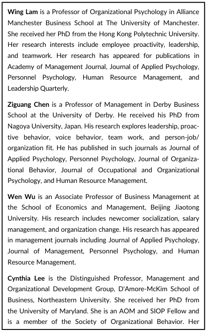

NOTE: figure/graphic rendered as an image from the PDF; its content is not machine-readable text. Caption (if any) follows as the next block.

**text found inside the figure**

Wing Lam is a Professor of Organizational Psychology in Alliance

Manchester Business School at The University of Manchester.

She received her PhD from the Hong Kong Polytechnic University.

Her research interests include employee proactivity, leadership,

and teamwork. Her research has appeared for publications in

Academy of Management Journal, Journal of Applied Psychology,

Personnel Psychology, Human Resource Management, and

Leadership Quarterly.

Ziguang Chen is a Professor of Management in Derby Business

School at the University of Derby. He received his PhD from

Nagoya University, Japan. His research explores leadership, proac-

tive behavior, voice behavior, team work, and person-job/

organization fit. He has published in such journals as Journal of

Applied Psychology, Personnel Psychology, Journal of Organiza-

tional Behavior, Journal of Occupational and Organizational

Psychology, and Human Resource Management.

Wen Wu is an Associate Professor of Business Management at

the School of Economics and Management, Beijing Jiaotong

University. His research includes newcomer socialization, salary

management, and organization change. His research has appeared

in management journals including Journal of Applied Psychology,

Journal of Management, Personnel Psychology, and Human

Resource Management.

Cynthia Lee is the Distinguished Professor, Management and

Organizational Development Group, D'Amore-McKim School of

Business, Northeastern University. She received her PhD from

the University of Maryland. She is an AOM and SIOP Fellow and

is a member of the Society of Organizational Behavior. Her

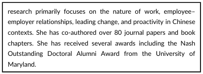

NOTE: figure/graphic rendered as an image from the PDF; its content is not machine-readable text. Caption (if any) follows as the next block.

**text found inside the figure**

research primarily focuses on the nature of work, employee–

employer relationships, leading change, and proactivity in Chinese

contexts. She has co-authored over 80 journal papers and book

chapters. She has received several awards including the Nash

Outstanding Doctoral Alumni Award from the University of

Maryland.

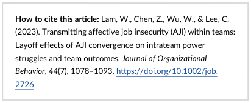

NOTE: figure/graphic rendered as an image from the PDF; its content is not machine-readable text. Caption (if any) follows as the next block.

**text found inside the figure**

How to cite this article: Lam, W., Chen, Z., Wu, W., & Lee, C.

(2023). Transmitting affective job insecurity (AJI) within teams:

Layoff effects of AJI convergence on intrateam power

struggles and team outcomes. Journal of Organizational

Behavior, 44(7), 1078–1093. https://doi.org/10.1002/job.

2726